# Project Draft A.S.

2023-04-16

# Background

> We read in the two datasets and create dataFrames “co2” and “sea_level”.

```r
co2 = read.csv("annual-co2-emissions-per-country.csv")
sea_level = read.csv("Global_sea_level_rise.csv")
```

> Data and variable description

### co2

- Dimensions: 31349 rows and 4 columns
- The co2 dataset has 4 variables - entity, code, year, annual.co2.emissions. Each row corresponds to each country, groups of countries in continents and continents and their Co2 emissions every year from earliest 1750 to 2021. But not all entities have data available for all years. “entity” refers to the country or continent or groups of countries in continent. “code” refers to the unique country code. “year” refers to the year. “annual.co2.emissions” refers to the annual co2 emissions of the entity of the respective year in tonnes.
- This data was collected from “https://ourworldindata.org/co2-dataset-sources”. Our World in Data collects its CO2 dataset sources from a variety of reputable sources, including national and international government agencies, academic research institutions, and intergovernmental organizations. The website’s CO2 emissions data comes primarily from the Carbon Dioxide Information Analysis Center (CDIAC), which is a research group within the Oak Ridge National Laboratory in the United States. CDIAC is responsible for collecting and disseminating data on greenhouse gas emissions, and Our World in Data cites them as one of their primary data sources for CO2 emissions. In addition to CDIAC, Our World in Data also references data from organizations such as the United Nations Framework Convention on Climate Change (UNFCCC), the Intergovernmental Panel on Climate Change (IPCC), and the World Bank, as well as numerous scientific publications and research papers. It strives to use the most reliable and up-to-date sources for their data, and they regularly review and update their datasets as new information becomes available. They use a variety of methods to collect this data, including direct measurements from monitoring stations around the world, satellite data, and atmospheric modeling.
- We will use it to analyse the trend of greenhouse emissions through the years, the total emission of the world through the years. We would also analyse who the main emitters are and how they vary within entities through continents and globally.
- This dataset has data about different entities - not just countries and also does not have data about some entities through all the years. These might result in some discrepancies, but on a global they still should be enough to show the trend on the global level. We can also just use Data that is complete for all countries through all years. We would do some data cleaning to extrapolate data for countries specifically and later only about the continents for analysing the data through the years.

### sea_level

- Dimensions: 141 rows and 3 columns
- The sea_level dataset has 3 variables - year, date, mmfrom1993.2008average. Each row corresponds to the mean sea level difference from the average mean sea level between 1993 to 2008 for each year. We wont be needing the date variable since we are only concerned with the yearly mean sea level and its analysis. “year” is the year of data observation. “mmfrom19993.2008average” is the mean sea level difference from the average mean sea level between 1993 to 2008. This is used so that the sea level can be conceptualized as relative to some quantity. The quantity here is the 1993-2008 mean sea level average.
- The data was collected from “https://www.kaggle.com/datasets/jarredpriester/global-sea-level-rise”. This dataset consist of global sea level rise as provided by climate.gov. The data used by Climate.gov for sea level analysis is gathered from a variety of sources, mainly satellite measurements, and additionally tide gauges, and other observational data. Satellite measurements are a critical source of information for sea level analysis because they provide a comprehensive view of the ocean surface. These measurements are obtained using altimeters, which bounce microwave pulses off the ocean surface and measure the time it takes for the signal to return. By analyzing the timing of these signals, scientists can determine the height of the ocean surface relative to a reference level. Other observational data used by Climate.gov to analyze sea level include measurements of ocean temperature and salinity. Changes in these parameters can impact sea level, so they are important factors to consider when analyzing sea level data.
- The table will be used to analyse and show the trend and overall correlation (if there exists one) between GreenHouse Emission and Sea Level through the years.
- The data produced may be different from data from different sources since a relative model is being used to measure the sea level. If the relative measure is different in a different source then the absolute difference would be different. However, that will not affect our analysis and visualizations since it is relative, so the overall trends will be apparent.

> Exploratory Data Analysis

#### sea_level

```r
sea_level$date
```

```
##   [1] "07/15/1880" "07/15/1881" "07/15/1882" "07/15/1883" "07/15/1884"
##   [6] "07/15/1885" "07/15/1886" "07/15/1887" "07/15/1888" "07/15/1889"
##  [11] "07/15/1890" "07/15/1891" "07/15/1892" "07/15/1893" "07/15/1894"
##  [16] "07/15/1895" "07/15/1896" "07/15/1897" "07/15/1898" "07/15/1899"
##  [21] "7/15/1900"  "7/15/1901"  "7/15/1902"  "7/15/1903"  "7/15/1904"
##  [26] "7/15/1905"  "7/15/1906"  "7/15/1907"  "7/15/1908"  "7/15/1909"
##  [31] "7/15/1910"  "7/15/1911"  "7/15/1912"  "7/15/1913"  "7/15/1914"
##  [36] "7/15/1915"  "7/15/1916"  "7/15/1917"  "7/15/1918"  "7/15/1919"
##  [41] "7/15/1920"  "7/15/1921"  "7/15/1922"  "7/15/1923"  "7/15/1924"
##  [46] "7/15/1925"  "7/15/1926"  "7/15/1927"  "7/15/1928"  "7/15/1929"
##  [51] "7/15/1930"  "7/15/1931"  "7/15/1932"  "7/15/1933"  "7/15/1934"
##  [56] "7/15/1935"  "7/15/1936"  "7/15/1937"  "7/15/1938"  "7/15/1939"
##  [61] "7/15/1940"  "7/15/1941"  "7/15/1942"  "7/15/1943"  "7/15/1944"
##  [66] "7/15/1945"  "7/15/1946"  "7/15/1947"  "7/15/1948"  "7/15/1949"
##  [71] "7/15/1950"  "7/15/1951"  "7/15/1952"  "7/15/1953"  "7/15/1954"
##  [76] "7/15/1955"  "7/15/1956"  "7/15/1957"  "7/15/1958"  "7/15/1959"
##  [81] "7/15/1960"  "7/15/1961"  "7/15/1962"  "7/15/1963"  "7/15/1964"
##  [86] "7/15/1965"  "7/15/1966"  "7/15/1967"  "7/15/1968"  "7/15/1969"
##  [91] "7/15/1970"  "7/15/1971"  "7/15/1972"  "7/15/1973"  "7/15/1974"
##  [96] "7/15/1975"  "7/15/1976"  "7/15/1977"  "7/15/1978"  "7/15/1979"
## [101] "7/15/1980"  "7/15/1981"  "7/15/1982"  "7/15/1983"  "7/15/1984"
## [106] "7/15/1985"  "7/15/1986"  "7/15/1987"  "7/15/1988"  "7/15/1989"
## [111] "7/15/1990"  "7/15/1991"  "7/15/1992"  "7/15/1993"  "7/15/1994"
## [116] "7/15/1995"  "7/15/1996"  "7/15/1997"  "7/15/1998"  "7/15/1999"
## [121] "7/15/2000"  "7/15/2001"  "7/15/2002"  "7/15/2003"  "7/15/2004"
## [126] "7/15/2005"  "7/15/2006"  "7/15/2007"  "7/15/2008"  "7/15/2009"
## [131] "7/15/2010"  "7/15/2011"  "7/15/2012"  "7/15/2013"  "7/15/2014"
## [136] "7/15/2015"  "7/15/2016"  "7/15/2017"  "7/15/2018"  "7/15/2019"
## [141] "7/15/2020"
```

- As we can observe, the date columns for all the years have the same date, that is 15th of July. This is the date that the data for the year was aggregated and published. Since this is the same for every year, we do not need the date column and will be dropping them for further analysis and use while cleaning.

#### co2

```r
summary(co2)
```

```
##     Entity              Code                Year      Annual.CO..emissions
##  Length:31349       Length:31349       Min.   :1750   Min.   :0.000e+00
##  Class :character   Class :character   1st Qu.:1897   1st Qu.:1.246e+05
##  Mode  :character   Mode  :character   Median :1956   Median :3.109e+06
##                                        Mean   :1937   Mean   :3.800e+08
##                                        3rd Qu.:1990   3rd Qu.:4.366e+07
##                                        Max.   :2021   Max.   :3.712e+10
```

- We observe that the min Co2 emissions are 0. This indicates that there are missing data values for some observations. The reason for this might be because of missing or unavailable data for those countries and years. It is better that we drop the data so that it doesn’t interfere with analysis later on.

```r
co2$Entity %>%
  unique()
```

```
##   [1] "Afghanistan"                      "Africa"
##   [3] "Africa (GCP)"                     "Albania"
##   [5] "Algeria"                          "Andorra"
##   [7] "Angola"                           "Anguilla"
##   [9] "Antarctica"                       "Antigua and Barbuda"
##  [11] "Argentina"                        "Armenia"
##  [13] "Aruba"                            "Asia"
##  [15] "Asia (GCP)"                       "Asia (excl. China and India)"
##  [17] "Australia"                        "Austria"
##  [19] "Azerbaijan"                       "Bahamas"
##  [21] "Bahrain"                          "Bangladesh"
##  [23] "Barbados"                         "Belarus"
##  [25] "Belgium"                          "Belize"
##  [27] "Benin"                            "Bermuda"
##  [29] "Bhutan"                           "Bolivia"
```

[output cut: 114 more lines]

- From the values generated we can also see the names of Continents and “World” and other such entities. So, for analysis, we need to divide the data and extrapolate the values for the world emissions, for individual countries through the years and by continents through the years. So we are going to create new datasets with the required values after cleaning.

> Cleaning the Data

```r
sea_level_f = sea_level %>%
  select(!date) %>%
  rename("Relative mean sea level (mm)" = "mmfrom1993.2008average")
sea_level_f
```

```
##     year Relative mean sea level (mm)
## 1   1880                 -183.2473958
## 2   1881                 -174.0140625
## 3   1882                 -190.0807292
## 4   1883                 -185.1473958
## 5   1884                 -166.2807292
## 6   1885                 -167.6807292
## 7   1886                 -164.2140625
## 8   1887                 -170.2140625
## 9   1888                 -172.6140625
## 10  1889                 -169.7140625
## 11  1890                 -166.9807292
## 12  1891                 -167.7140625
## 13  1892                 -167.5807292
## 14  1893                 -162.9807292
```

[output cut: 127 more lines]

```r
co2 = co2 %>%
  filter(Year >= 1880)

co2_per_year = co2 %>%
  filter(Code != "" & Code != "OWID_WRL") %>%
  group_by(Year) %>%
  summarize(Annual_CO2_tonnes = sum(Annual.CO..emissions), Annual_CO2_million_tonnes = Annual_CO2_tonnes / 1000000)
co2_per_year
```

```
## # A tibble: 142 × 3
##     Year Annual_CO2_tonnes Annual_CO2_million_tonnes
##    <int>             <dbl>                     <dbl>
##  1  1880        853704680                       854.
##  2  1881        882405009.                      882.
##  3  1882        931921917.                      932.
##  4  1883        991032430                       991.
##  5  1884       1002174273                      1002.
##  6  1885       1009671348.                     1010.
##  7  1886       1025475453.                     1025.
##  8  1887       1076757782.                     1077.
##  9  1888       1192271843.                     1192.
## 10  1889       1191799629                      1192.
## # … with 132 more rows
```

```r
co2_by_country = co2 %>%
  filter(Code != "" & Code != "OWID_WRL") %>%
  group_by(Year, Entity) %>%
  summarize(Annual_CO2_tonnes = sum(Annual.CO..emissions), Annual_CO2_million_tonnes = Annual_CO2_tonnes / 1000000) %>%
  filter(Annual_CO2_tonnes != 0)
co2_by_country
```

```
## # A tibble: 19,711 × 4
## # Groups:   Year [142]
##     Year Entity     Annual_CO2_tonnes Annual_CO2_million_tonnes
##    <int> <chr>                  <dbl>                     <dbl>
##  1  1880 Armenia                31004                    0.0310
##  2  1880 Australia            2205728                    2.21
##  3  1880 Austria             23647456                   23.6
##  4  1880 Azerbaijan            186768                    0.187
##  5  1880 Belarus               390888                    0.391
##  6  1880 Belgium             30425856                   30.4
##  7  1880 Canada               5232192                    5.23
##  8  1880 Czechia             15564351                   15.6
##  9  1880 Denmark              1861312                    1.86
## 10  1880 Estonia               141330                    0.141
## # … with 19,701 more rows
```

```r
co2_by_continent = co2 %>%
  filter(Code == "" & Code != "OWID_WRL", Entity %in% c("Asia", "Europe", "Africa", "North America", "South America", "Australia")) %>%
  group_by(Year, Entity) %>%
  summarize(Annual_CO2_tonnes = sum(Annual.CO..emissions), Annual_CO2_million_tonnes = Annual_CO2_tonnes / 1000000) %>%
  filter(Annual_CO2_tonnes != 0)
co2_by_continent
```

```
## # A tibble: 702 × 4
## # Groups:   Year [142]
##     Year Entity        Annual_CO2_tonnes Annual_CO2_million_tonnes
##    <int> <chr>                     <dbl>                     <dbl>
##  1  1880 Asia                    6191159                      6.19
##  2  1880 Europe                640735500                    641.
##  3  1880 North America         203916430                    204.
##  4  1881 Asia                    6350417                      6.35
##  5  1881 Europe                657767940                    658.
##  6  1881 North America         215784160                    216.
##  7  1882 Asia                    6878992                      6.88
##  8  1882 Europe                680192200                    680.
##  9  1882 North America         242011140                    242.
## 10  1883 Asia                    7607270                      7.61
## # … with 692 more rows
```

We have cleaned the Data to create 4 new datasets. The “sea_level_f” dataset corresponds to the sea_level datasets with the date coumn dropped. The “co2_per_year” dataset corresponds to only aggregate the Data for the whole world through the years extrapolated from the co2 dataset. The “co2_by_country” dataset corresponds to the aggregate data for only the countries through the years and “co2_by_continent” dataset corresponds to only aggregate data for only the continents through the years. We have also dropped rows with missing data for the co2 emissions. We also have only included data 1880 onwards for the co2 dataset and the derived datasets for consistancy with the sea_level dataset and due to a large number of missing values for those years for a lot of countries.

> More Information Regarding Data

Some analysis and visualizations of the data.

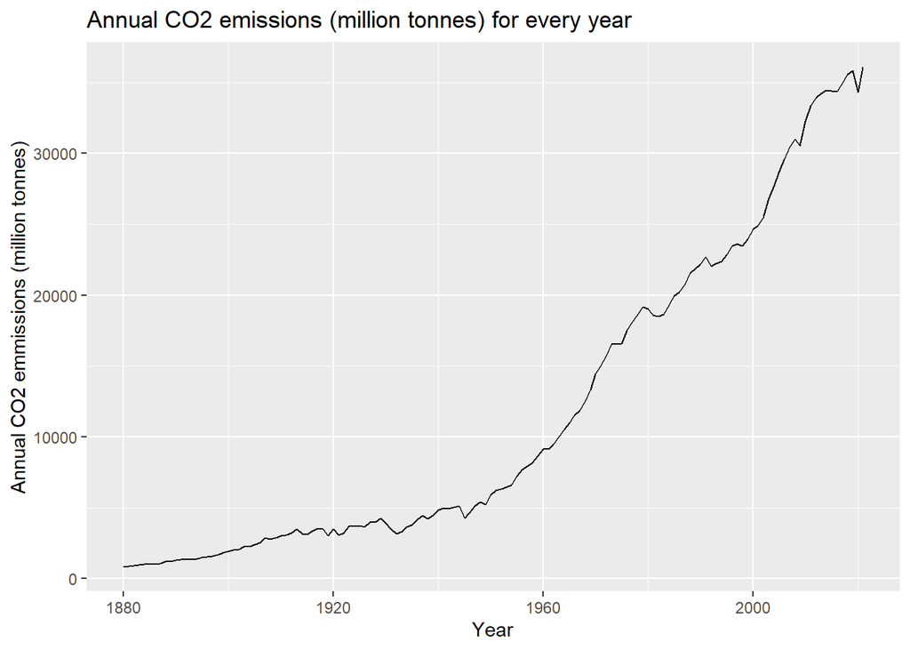

```r
ggplot(co2_per_year, aes(x=Year, y=Annual_CO2_million_tonnes)) +
  geom_line() +
  xlab("Year") +
  ylab("Annual CO2 emmissions (million tonnes)") +
  ggtitle("Annual CO2 emissions (million tonnes) for every year")
```